# Estratificación Rural

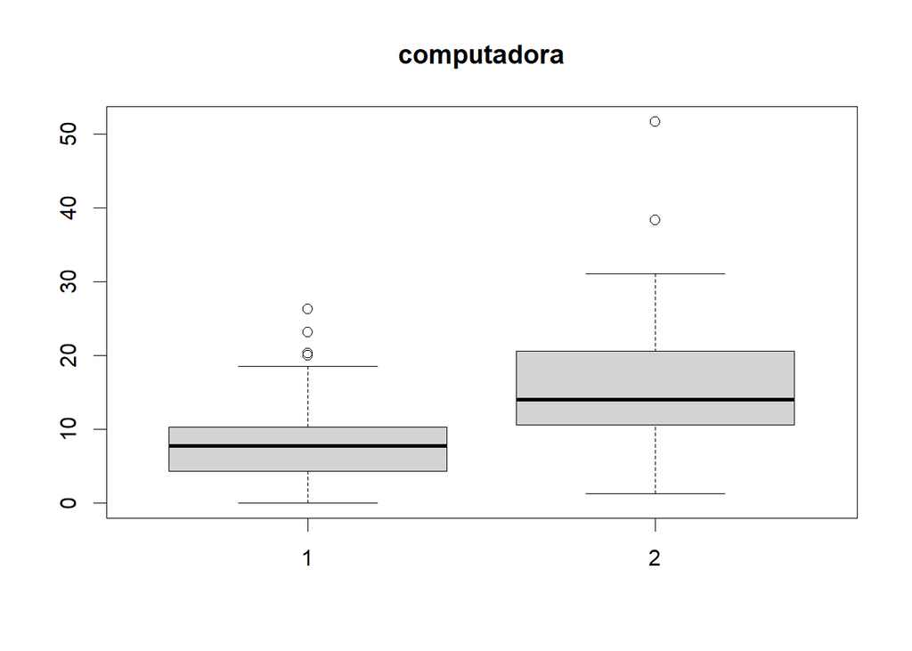

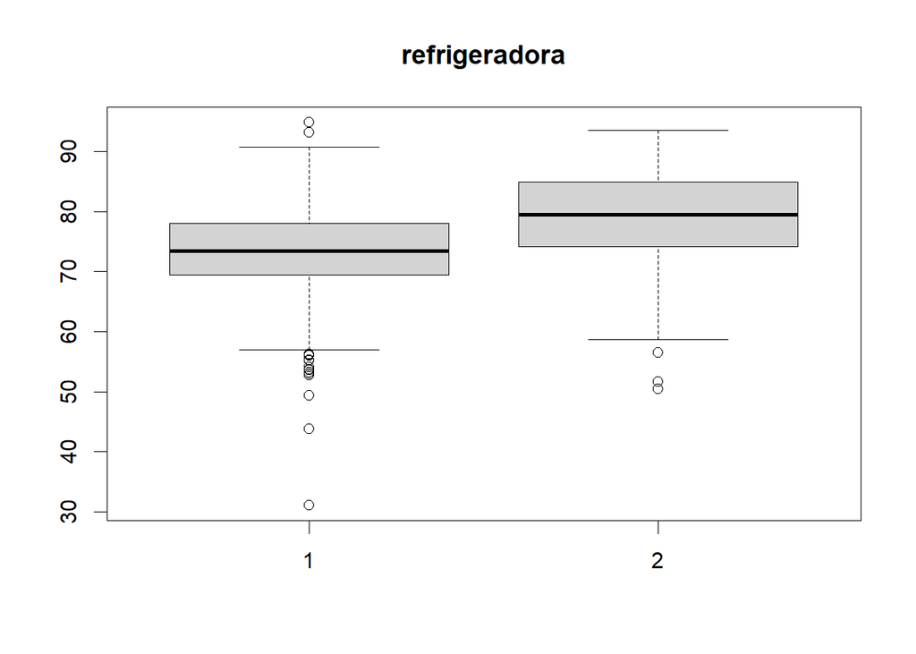

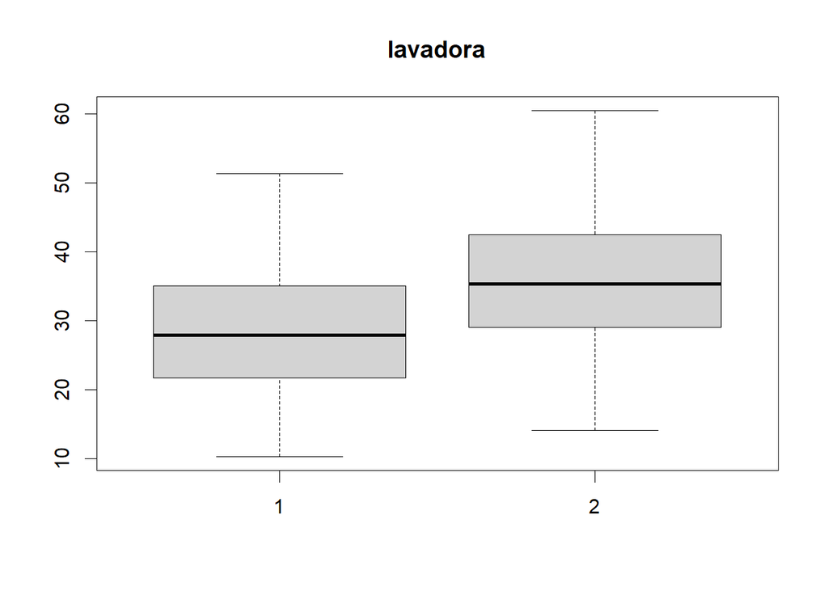

[7 more figures not shown]

Menor diseño de efecto generalizado

En base a los resultados obtenidos en el escenario 1 y 2, podemos concluir con evidencia estadística que el menor efecto de diseño generalizado se presenta en el escenario 2, por lo cual los resultados siguientes son evaluados en base a dicho escenario.

Dado que el efecto de diseño no es el único parámetro a evaluar para elegir el mejor procedimiento de estratificación, se presenta la siguiente matriz de coincidencias entre las diferentes clasificaciones de los estratos, que permite evaluar la estabilidad del método con respecto a otros procedimientos de estratificación.

Matriz de coincidencias

|  | Percentiles | Dalenius | LH_Sethi | LH_Kozak | Geometric | Jarque | Kmeans |
| --- | --- | --- | --- | --- | --- | --- | --- |
| Percentiles | 1,00 | 0,88 | 0,85 | 0,83 | 0,71 | 0,71 | 0,76 |
| Dalenius | 0,88 | 1,00 | 0,98 | 0,95 | 0,83 | 0,83 | 0,80 |
| LH_Sethi | 0,85 | 0,98 | 1,00 | 0,98 | 0,85 | 0,86 | 0,79 |
| LH_Kozak | 0,83 | 0,95 | 0,98 | 1,00 | 0,88 | 0,88 | 0,81 |
| Geometric | 0,71 | 0,83 | 0,85 | 0,88 | 1,00 | 1,00 | 0,81 |
| Jarque | 0,71 | 0,83 | 0,86 | 0,88 | 1,00 | 1,00 | 0,81 |
| Kmeans | 0,76 | 0,80 | 0,79 | 0,81 | 0,81 | 0,81 | 1,00 |